# Categorical data and crossvalidation

Peter Ralph

28 January 2020 – Advanced Biological Statistics

# Gene ontology enrichment

## Recall: the data

```r
(goterms <- read.table("data/go_terms.tsv", header=TRUE))
```

```
##              top                    term num_genes upregulated downregulated
## 1     cell death            neuron death      2405         122            70
## 2     cell death        oxidative stress       886          41            25
## 3     cell death                necrotic        32           2             0
## 4     cell death               apoptosis       898         468           123
## 5  cell motility    actin polymerization      1822         243           117
## 6  cell motility          sperm motility      1585         292           131
## 7  cell motility                   cilia       517          75            25
## 8  cell motility         axis elongation        62           9             5
## 9  ion transport         anion transport       128           2             5
## 10 ion transport        cation transport      1697          91            50
## 11 ion transport transmembrane transport        99           3             2
```

Are some categories of genes more likely to be differentially regulated than others? or, upregulated? downregulated?

## First, look at the data

```r
goterms$per_up <- with(goterms, upregulated/sum(upregulated))
goterms$per_down <- with(goterms, downregulated/sum(downregulated))
goterms$per_diff <- with(goterms, (upregulated + downregulated)/sum(upregulated + downregulated))
goterms$per_nodiff <- with(goterms, (num_genes - upregulated + downregulated)/sum(num_genes - upregulated + downregulated))
goterms$diff_enrich <- goterms$per_diff / goterms$per_nodiff
goterms$up_vs_down <- goterms$per_up / goterms$per_down
goterms
```

```
##              top                    term num_genes upregulated downregulated per_up per_down per_diff per_nodiff diff_enrich up_vs_down
## 1     cell death            neuron death      2405         122            70 0.0905   0.1266   0.1010     0.2520        0.40       0.71
## 2     cell death        oxidative stress       886          41            25 0.0304   0.0452   0.0347     0.0932        0.37       0.67
## 3     cell death                necrotic        32           2             0 0.0015   0.0000   0.0011     0.0032        0.33        Inf
## 4     cell death               apoptosis       898         468           123 0.3472   0.2224   0.3109     0.0592        5.25       1.56
## 5  cell motility    actin polymerization      1822         243           117 0.1803   0.2116   0.1894     0.1817        1.04       0.85
## 6  cell motility          sperm motility      1585         292           131 0.2166   0.2369   0.2225     0.1525        1.46       0.91
## 7  cell motility                   cilia       517          75            25 0.0556   0.0452   0.0526     0.0500        1.05       1.23
## 8  cell motility         axis elongation        62           9             5 0.0067   0.0090   0.0074     0.0062        1.19       0.74
## 9  ion transport         anion transport       128           2             5 0.0015   0.0090   0.0037     0.0140        0.26       0.16
## 10 ion transport        cation transport      1697          91            50 0.0675   0.0904   0.0742     0.1774        0.42       0.75
## 11 ion transport transmembrane transport        99           3             2 0.0022   0.0036   0.0026     0.0105        0.25       0.62
```

## The poisson model

Let

$$\begin{aligned}
N_i &= (\text{number of no difference genes in category $i$}) \\
&\sim \Poisson(\exp(\lambda_i^N)) \\
U_i &= (\text{number of upregulated genes in category $i$}) \\
&\sim \Poisson(\exp(\lambda_i^U)) \\
D_i &= (\text{number of downregulated genes in category $i$}) \\
&\sim \Poisson(\exp(\lambda_i^D)) .
\end{aligned}$$

and

$$\begin{aligned}
\lambda_i^N &= \alpha_i \\
\lambda_i^U &= \alpha_i + \delta_U + \beta_1[\text{top}_i] + \beta_2[i] \\
\lambda_i^D &= \alpha_i + \delta_D + \beta_1[\text{top}_i] + \beta_2[i] + \gamma_i.
\end{aligned}$$

## Our Stan code: flat priors

```r
go_model_code <- "
data {
    int nterms;
    int ntop; // number of 'top' categories
    int N[nterms];
    int U[nterms];
    int D[nterms];
    int top[nterms];
}
parameters {
    real alpha[nterms];
    real delta[2]; // up, down regulation
    real beta1[ntop];
    real beta2[nterms];
    real gamma[nterms];
}
model {
    real lambda_n;
    real lambda_u;
    real lambda_d;
    for (i in 1:nterms) {
        lambda_n = alpha[i];
        lambda_u = alpha[i] + delta[1] + beta1[top[i]] + beta2[i];
        lambda_d = alpha[i] + delta[2] + beta1[top[i]] + beta2[i] + gamma[i];
        N[i] ~ poisson(exp(lambda_n));
        U[i] ~ poisson(exp(lambda_u));
        D[i] ~ poisson(exp(lambda_d));
    }
}
"
go_model <- stan_model(model_code=go_model_code)
```

```r
go_fit <- sampling(go_model, chains = 4, iter = 2000,
                   data=list(nterms = nrow(goterms),
                             ntop = nlevels(goterms$top),
                             N = goterms$num_genes - goterms$upregulated - goterms$downregulated,
                             U = goterms$upregulated,
                             D = goterms$downregulated,
                             top = as.numeric(goterms$top)))
```

```
##              mean se_mean      sd    2.5%     25%     50%     75%     98% n_eff Rhat
## alpha[1]      7.7 2.2e-03   0.020     7.7     7.7     7.7     7.7     7.7  81.7  1.0
## alpha[2]      6.7 4.6e-03   0.033     6.6     6.7     6.7     6.7     6.8  50.0  1.1
## alpha[3]      3.4 2.6e-02   0.200     3.0     3.2     3.4     3.5     3.7  57.4  1.1
## alpha[4]      5.7 5.5e-03   0.053     5.6     5.7     5.7     5.8     5.8  90.9  1.0
## alpha[5]      7.3 3.1e-03   0.026     7.2     7.3     7.3     7.3     7.3  69.0  1.1
## alpha[6]      7.0 5.4e-03   0.033     7.0     7.0     7.1     7.1     7.1  37.1  1.1
## alpha[7]      6.0 7.4e-03   0.055     5.9     6.0     6.0     6.1     6.1  55.0  1.1
## alpha[8]      3.9 2.1e-02   0.148     3.6     3.8     3.9     4.0     4.2  48.8  1.1
## alpha[9]      4.8 1.1e-02   0.090     4.6     4.7     4.8     4.9     5.0  67.4  1.0
## alpha[10]     7.4 2.1e-03   0.022     7.3     7.3     7.4     7.4     7.4 108.6  1.0
## alpha[11]     4.5 1.4e-02   0.110     4.3     4.5     4.5     4.6     4.7  62.9  1.1
## delta[1]    124.9 1.4e+02 199.883  -137.9   -50.7    90.8   275.1   464.9   2.1  7.7
## delta[2]    164.0 1.2e+02 173.357  -121.7     2.0   164.6   297.6   448.1   2.1  6.0
## beta1[1]    -41.0 1.3e+02 201.879  -377.1  -208.9   -77.8   174.0   277.0   2.4  4.2
## beta1[2]    -94.0 7.2e+01 109.531  -250.0  -189.9  -109.0     5.6   108.5   2.3  3.7
## beta1[3]    -27.8 1.3e+02 213.203  -397.8  -172.0   -15.9   154.2   305.3   2.7  3.7
## beta2[1]    -86.8 1.6e+02 237.618  -473.6  -283.3   -98.6    80.9   304.2   2.1  6.4
## beta2[2]    -86.9 1.6e+02 237.619  -474.0  -283.5   -98.8    80.9   303.7   2.1  6.4
## beta2[3]    -86.8 1.6e+02 237.658  -474.1  -283.2   -98.5    79.3   304.2   2.1  6.4
## beta2[4]    -83.4 1.6e+02 237.627  -470.2  -279.9   -95.3    84.2   307.3   2.1  6.4
## beta2[5]    -32.6 9.0e+01 131.971  -291.3   -67.2   -16.9    19.2   194.9   2.1  5.8
## beta2[6]    -32.2 9.0e+01 131.973  -290.9   -66.7   -16.5    19.6   195.2   2.1  5.8
## beta2[7]    -32.5 9.0e+01 131.954  -291.2   -67.1   -16.9    19.3   194.9   2.1  5.8
## beta2[8]    -32.5 9.0e+01 131.987  -291.3   -67.0   -16.9    19.1   194.9   2.1  5.8
## beta2[9]   -101.4 3.4e+01 100.484  -239.4  -177.7  -113.3   -56.2   143.9   8.6  1.9
## beta2[10]   -99.9 3.4e+01 100.481  -237.8  -176.0  -111.9   -54.5   144.4   8.6  1.9
## beta2[11]  -100.7 3.4e+01 100.485  -238.2  -176.6  -112.6   -55.6   143.4   8.6  1.9
## gamma[1]    -39.7 3.8e+01  54.962  -160.0   -53.3   -24.1     7.8    16.7   2.1  4.6
## gamma[2]    -39.6 3.8e+01  54.963  -160.4   -53.1   -24.2     7.7    16.8   2.1  4.6
## gamma[3]   -421.3 9.6e+01 235.064  -818.7  -625.3  -428.2  -221.7   -16.7   6.0  1.4
## gamma[4]    -40.5 3.8e+01  54.964  -160.9   -54.2   -25.0     7.1    16.0   2.1  4.6
## gamma[5]    -39.9 3.8e+01  54.965  -160.3   -53.6   -24.2     7.6    16.6   2.1  4.6
## gamma[6]    -39.9 3.8e+01  54.962  -160.4   -53.7   -24.2     7.6    16.5   2.1  4.6
## gamma[7]    -40.3 3.8e+01  54.963  -160.7   -54.2   -24.4     7.1    16.2   2.1  4.6
## gamma[8]    -39.8 3.8e+01  54.957  -160.1   -53.4   -24.0     7.6    16.8   2.1  4.6
## gamma[9]    -38.1 3.8e+01  54.940  -158.8   -52.3   -22.5     8.8    18.7   2.1  4.5
## gamma[10]   -39.8 3.8e+01  54.964  -160.0   -53.3   -24.0     7.7    16.7   2.1  4.6
## gamma[11]   -39.6 3.8e+01  54.994  -160.2   -53.5   -23.8     7.3    17.3   2.1  4.6
## lp__      58087.8 2.0e-01   3.983 58079.1 58085.2 58088.1 58090.6 58094.8 391.9  1.0
```

## Uh-oh!! Rhat values:

```
##  alpha[1]  alpha[2]  alpha[3]  alpha[4]  alpha[5]  alpha[6]  alpha[7]  alpha[8]  alpha[9] alpha[10] alpha[11]  delta[1]  delta[2]  beta1[1]  beta1[2]  beta1[3]  beta2[1]  beta2[2]  beta2[3]  beta2[4]  beta2[5]
##       1.0       1.1       1.1       1.0       1.1       1.1       1.1       1.1       1.0       1.0       1.1       7.7       6.0       4.2       3.7       3.7       6.4       6.4       6.4       6.4       5.8
##  beta2[6]  beta2[7]  beta2[8]  beta2[9] beta2[10] beta2[11]  gamma[1]  gamma[2]  gamma[3]  gamma[4]  gamma[5]  gamma[6]  gamma[7]  gamma[8]  gamma[9] gamma[10] gamma[11]      lp__
##       5.8       5.8       5.8       1.9       1.9       1.9       4.6       4.6       1.4       4.6       4.6       4.6       4.6       4.6       4.5       4.6       4.6       1.0
```

## Traces, alpha

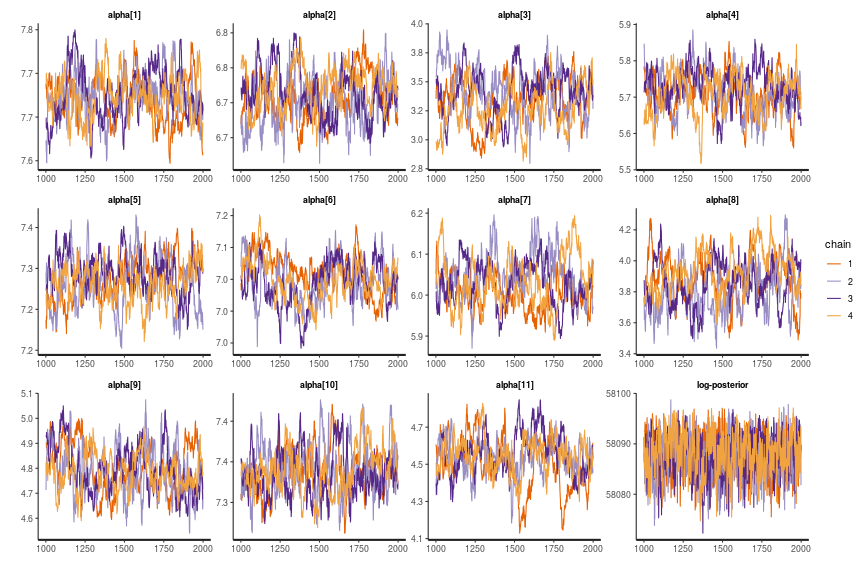

## Traces, gamma

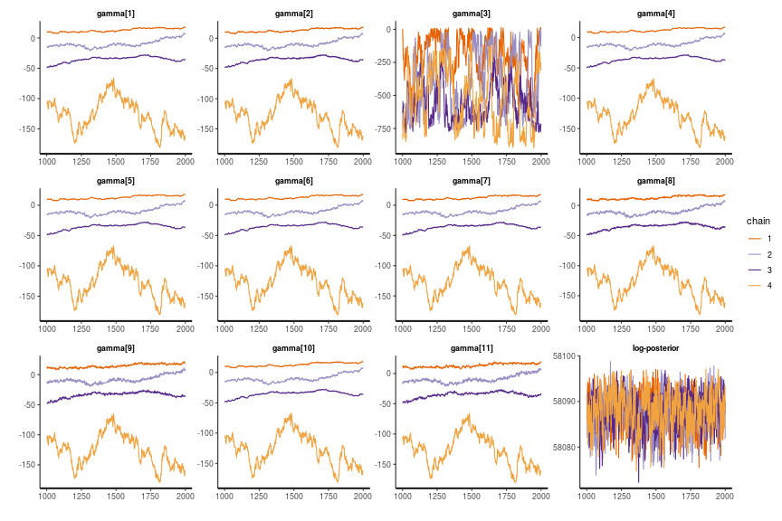

## `pairs()`

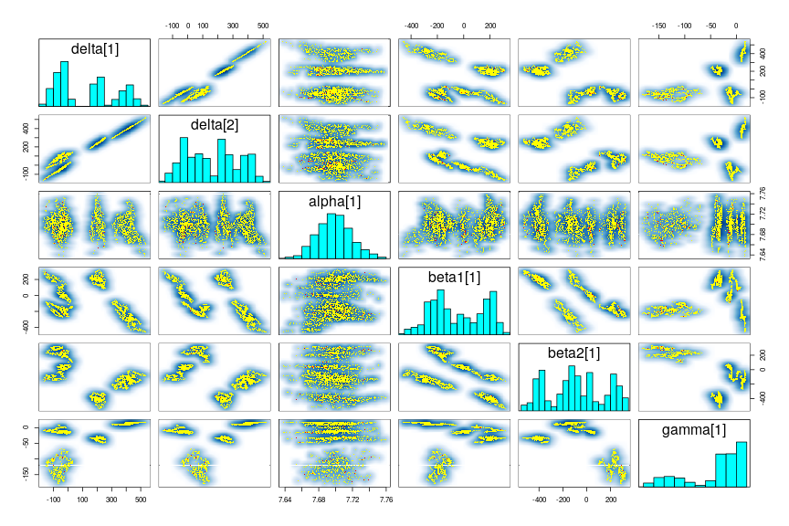

# R interlude

## Indexing with names is good!!

Number of ‘high’ values:

```r
y <- rnorm(1e4)
# cutoffs:
x <- c(1, 2, 3)
sum(y > x[3])
```

```
## [1] 11
```

Wait, let’s make more cutoffs:

```r
x <- c(1, 1.5, 2.5, 3)
sum(y > x[3])
```

```
## [1] 49
```

. . . whoops!

Wait, let’s add another level:

```r
x <- c(low=1, "lowish"=1.5, 'highish'=2.5, high=3)
sum(y > x['high'])
```

```
## [1] 11
```

## BUT: A warning about factors

```r
f <- factor(c('low', 'med', 'high'))
x <- c(low=1, med=2, high=3)
```

What is `x[f[3]]`?

```r
x[f[3]]
```

```
## low
##   1
```

## Defensive programming

```r
xf <- x[f]
stopifnot(all(names(xf) == f))
```

```
## Error in templater::render_template("Week_14_Lecture.Rmd", output = "Week_14_Lecture.md", : all(names(xf) == f) is not TRUE
```

```r
xf <- x[as.character(f)]
stopifnot(all(names(xf) == f))
```

# The effect of priors

## Same model, with priors

```r
go_model_code2 <- "
data {
    int nterms;
    int ntop; // number of 'top' categories
    int N[nterms];
    int U[nterms];
    int D[nterms];
    int top[nterms];
}
parameters {
    real alpha[nterms];
    real delta[2]; // up, down regulation
    real beta1[ntop];
    real beta2[nterms];
    real gamma[nterms];
}
model {
    real lambda_n;
    real lambda_u;
    real lambda_d;
    for (i in 1:nterms) {
        lambda_n = alpha[i];
        lambda_u = alpha[i] + delta[1] + beta1[top[i]] + beta2[i];
        lambda_d = alpha[i] + delta[2] + beta1[top[i]] + beta2[i] + gamma[i];
        N[i] ~ poisson(exp(lambda_n));
        U[i] ~ poisson(exp(lambda_u));
        D[i] ~ poisson(exp(lambda_d));
    }
    alpha ~ normal(0, 5); // flat-ish
    delta ~ normal(0, 5); // flat-ish
    beta1 ~ cauchy(0, 0.1); // very peaked
    beta2 ~ cauchy(0, 0.1); // very peaked
    gamma ~ cauchy(0, 0.1); // very peaked
}
"
go_model2 <- stan_model(model_code=go_model_code2)
```

## Fit, again

```r
go_fit2 <- sampling(go_model2, chains = 4, iter = 2000,
                    data=list(nterms = nrow(goterms),
                              ntop = nlevels(goterms$top),
                              N = goterms$num_genes - goterms$upregulated - goterms$downregulated,
                              U = goterms$upregulated,
                              D = goterms$downregulated,
                              top = as.numeric(goterms$top)))
```

```
##               mean se_mean    sd     2.5%      25%      50%      75%      98% n_eff Rhat
## alpha[1]   7.7e+00 0.00027 0.021  7.7e+00  7.7e+00  7.7e+00  7.7e+00     7.74  5949    1
## alpha[2]   6.7e+00 0.00047 0.034  6.6e+00  6.7e+00  6.7e+00  6.7e+00     6.77  5339    1
## alpha[3]   3.4e+00 0.00278 0.182  3.0e+00  3.3e+00  3.4e+00  3.5e+00     3.71  4288    1
## alpha[4]   5.7e+00 0.00080 0.057  5.6e+00  5.7e+00  5.7e+00  5.8e+00     5.83  5044    1
## alpha[5]   7.3e+00 0.00037 0.027  7.2e+00  7.3e+00  7.3e+00  7.3e+00     7.34  5268    1
## alpha[6]   7.1e+00 0.00045 0.029  7.0e+00  7.0e+00  7.1e+00  7.1e+00     7.12  4138    1
## alpha[7]   6.0e+00 0.00071 0.048  5.9e+00  6.0e+00  6.0e+00  6.1e+00     6.12  4513    1
## alpha[8]   3.9e+00 0.00208 0.135  3.6e+00  3.8e+00  3.9e+00  4.0e+00     4.13  4219    1
## alpha[9]   4.8e+00 0.00133 0.090  4.6e+00  4.7e+00  4.8e+00  4.8e+00     4.95  4651    1
## alpha[10]  7.4e+00 0.00038 0.026  7.3e+00  7.3e+00  7.4e+00  7.4e+00     7.40  4626    1
## alpha[11]  4.5e+00 0.00150 0.103  4.3e+00  4.4e+00  4.5e+00  4.6e+00     4.71  4777    1
## delta[1]  -2.8e+00 0.01876 0.271 -3.2e+00 -3.0e+00 -2.9e+00 -2.8e+00    -1.87   209    1
## delta[2]  -3.5e+00 0.01861 0.282 -3.9e+00 -3.7e+00 -3.6e+00 -3.5e+00    -2.59   230    1
## beta1[1]  -7.4e-02 0.01829 0.262 -1.0e+00 -1.1e-01 -1.8e-02  4.8e-02     0.25   205    1
## beta1[2]   1.1e+00 0.01900 0.304  9.8e-02  9.8e-01  1.1e+00  1.3e+00     1.55   257    1
## beta1[3]  -9.6e-02 0.01894 0.269 -1.0e+00 -1.3e-01 -3.3e-02  3.7e-02     0.21   202    1
## beta2[1]   1.0e-02 0.00245 0.116 -2.3e-01 -5.2e-02  9.3e-03  7.3e-02     0.24  2225    1
## beta2[2]  -3.2e-02 0.00238 0.120 -3.0e-01 -9.1e-02 -2.2e-02  3.9e-02     0.19  2533    1
## beta2[3]  -3.4e-02 0.00598 0.247 -6.4e-01 -1.0e-01 -1.0e-02  7.1e-02     0.41  1710    1
## beta2[4]   3.3e+00 0.00295 0.137  3.0e+00  3.2e+00  3.3e+00  3.4e+00     3.57  2139    1
## beta2[5]  -6.1e-02 0.00301 0.123 -3.5e-01 -1.3e-01 -4.4e-02  1.7e-02     0.15  1662    1
## beta2[6]   3.1e-01 0.00346 0.144  3.1e-03  2.2e-01  3.1e-01  4.0e-01     0.58  1730    1
## beta2[7]  -3.5e-02 0.00275 0.121 -3.3e-01 -9.4e-02 -2.4e-02  3.6e-02     0.19  1945    1
## beta2[8]   1.7e-02 0.00325 0.160 -3.1e-01 -5.9e-02  1.3e-02  8.7e-02     0.38  2423    1
## beta2[9]  -1.0e-01 0.00536 0.228 -6.9e-01 -1.7e-01 -5.3e-02  2.2e-02     0.21  1809    1
## beta2[10]  6.5e-02 0.00361 0.146 -1.6e-01 -2.0e-02  4.3e-02  1.2e-01     0.44  1631    1
## beta2[11] -9.2e-02 0.00630 0.228 -7.1e-01 -1.5e-01 -4.0e-02  3.3e-02     0.22  1309    1
## gamma[1]   8.5e-02 0.00222 0.125 -1.2e-01  2.5e-03  6.7e-02  1.6e-01     0.37  3199    1
## gamma[2]   5.6e-02 0.00258 0.145 -1.9e-01 -3.0e-02  3.8e-02  1.3e-01     0.40  3138    1
## gamma[3]  -2.3e-01 0.04488 0.873 -2.9e+00 -1.7e-01 -3.3e-02  6.1e-02     0.45   378    1
## gamma[4]  -5.7e-01 0.00236 0.139 -8.5e-01 -6.7e-01 -5.7e-01 -4.8e-01    -0.30  3466    1
## gamma[5]  -9.5e-03 0.00159 0.095 -2.0e-01 -6.2e-02 -7.7e-03  4.6e-02     0.18  3525    1
## gamma[6]  -3.1e-02 0.00168 0.098 -2.5e-01 -8.5e-02 -2.6e-02  2.9e-02     0.15  3396    1
## gamma[7]  -1.6e-01 0.00404 0.195 -6.5e-01 -2.6e-01 -1.1e-01 -3.0e-02     0.11  2321    1
## gamma[8]   1.7e-02 0.00530 0.208 -3.4e-01 -6.5e-02  8.9e-03  9.3e-02     0.46  1538    1
## gamma[9]   1.0e-01 0.00651 0.262 -2.7e-01 -3.8e-02  4.3e-02  1.8e-01     0.80  1617    1
## gamma[10]  6.6e-02 0.00238 0.128 -1.5e-01 -1.5e-02  4.9e-02  1.3e-01     0.37  2904    1
## gamma[11] -3.0e-02 0.00550 0.251 -6.6e-01 -9.8e-02 -6.9e-03  7.4e-02     0.42  2075    1
## lp__       5.8e+04 0.20568 5.730  5.8e+04  5.8e+04  5.8e+04  5.8e+04 58054.32   776    1
```

## `stan_trace()`, alpha

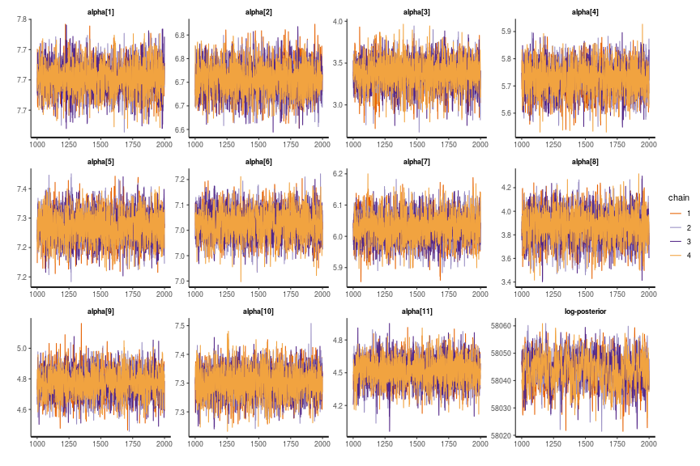

## `stan_trace()`, gamma

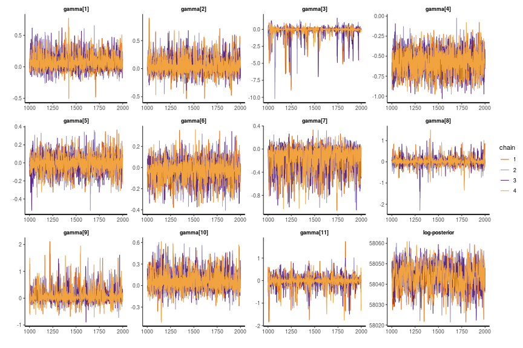

## `pairs()`

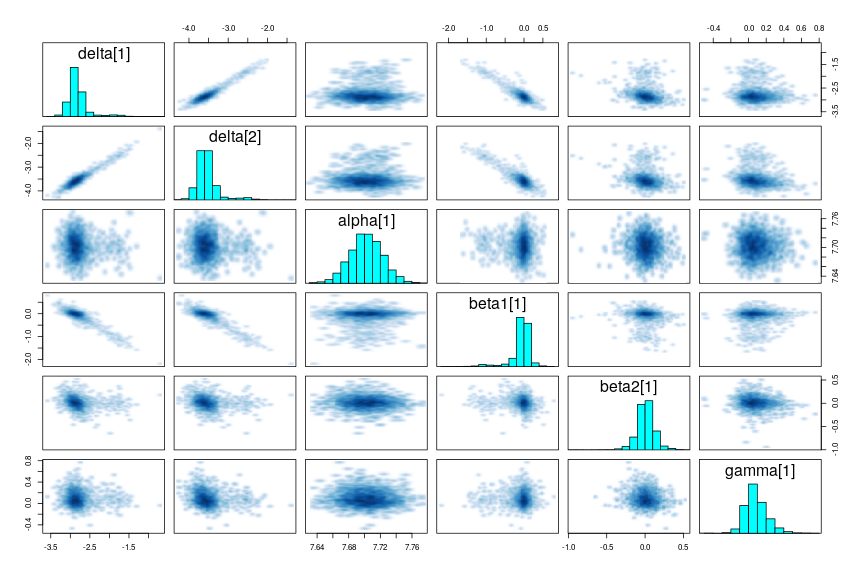

## Parameter estimates: main effects

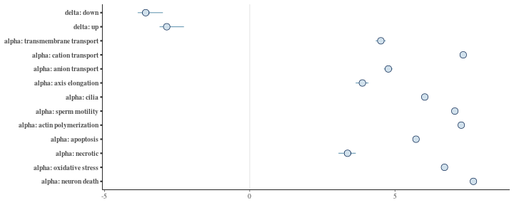

## Parameter estimates: differential regulation

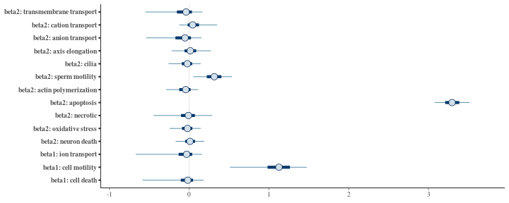

## Parameter estimates: down- versus upregulation

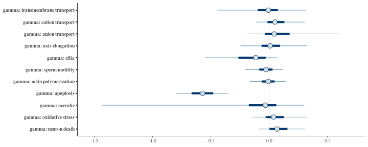

## in-class: conclusions

# Crossvalidation

## A common workflow

It’s often important to consider more than one model, e.g.:

- different explanatory variables
- simple/complex
- different response distributions
- different priors

The problem is that then there’s *more than one answer*.

How do we compare models?

# Variable selection

## Example data

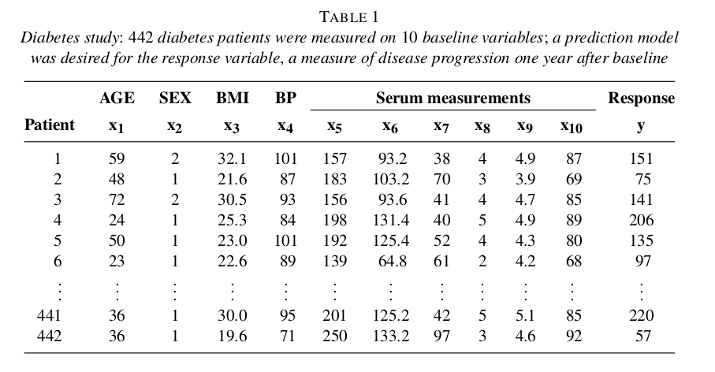

from Efron, Hastie, Johnstone, & Tibshirani

```r
library(lars)
data(diabetes)
class(diabetes$x2) <- "matrix"
```

```
diabetes                 package:lars                  R Documentation

Blood and other measurements in diabetics

Description:

     The ‘diabetes’ data frame has 442 rows and 3 columns. These are
     the data used in the Efron et al "Least Angle Regression" paper.

Format:

     This data frame contains the following columns:

     x a matrix with 10 columns

     y a numeric vector

     x2 a matrix with 64 columns
```

The dataset has

- 442 diabetes patients
- 10 main variables: age, gender, body mass index, average blood pressure (map), and six blood serum measurements (tc, ldl, hdl, tch, ltg, glu)
- 45 interactions, e.g. `age:ldl`
- 9 quadratic effects, e.g. `age^2`
- measure of disease progression taken one year later: `y`

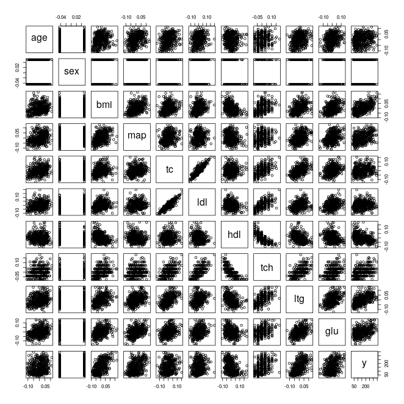

```r
cor(cbind(diabetes$x, y=diabetes$y))
```

```
##        age    sex    bmi   map    tc   ldl    hdl   tch   ltg   glu      y
## age  1.000  0.174  0.185  0.34 0.260  0.22 -0.075  0.20  0.27  0.30  0.188
## sex  0.174  1.000  0.088  0.24 0.035  0.14 -0.379  0.33  0.15  0.21  0.043
## bmi  0.185  0.088  1.000  0.40 0.250  0.26 -0.367  0.41  0.45  0.39  0.586
## map  0.335  0.241  0.395  1.00 0.242  0.19 -0.179  0.26  0.39  0.39  0.441
## tc   0.260  0.035  0.250  0.24 1.000  0.90  0.052  0.54  0.52  0.33  0.212
## ldl  0.219  0.143  0.261  0.19 0.897  1.00 -0.196  0.66  0.32  0.29  0.174
## hdl -0.075 -0.379 -0.367 -0.18 0.052 -0.20  1.000 -0.74 -0.40 -0.27 -0.395
## tch  0.204  0.332  0.414  0.26 0.542  0.66 -0.738  1.00  0.62  0.42  0.430
## ltg  0.271  0.150  0.446  0.39 0.516  0.32 -0.399  0.62  1.00  0.46  0.566
## glu  0.302  0.208  0.389  0.39 0.326  0.29 -0.274  0.42  0.46  1.00  0.382
## y    0.188  0.043  0.586  0.44 0.212  0.17 -0.395  0.43  0.57  0.38  1.000
```

## Crossvalidation plan

1. Put aside 20% of the data for *testing*.
2. Refit the model.
3. Predict the test data; compute
   $$\begin{aligned}
   S = \sqrt{\frac{1}{M} \sum_{k=1}^M (\hat y_i - y_i)^2}
   \end{aligned}$$
4. Repeat for the other four 20%s.
5. Compare.

## Crossvalidation

First let’s split the data into testing and training just once:

```r
test_indices <- (rbinom(length(diabetes$y), size=1, prob=0.2) == 1)
test_d <- cbind(data.frame(y=diabetes$y[test_indices]),
                diabetes$x2[test_indices,])
training_d <- cbind(data.frame(y=diabetes$y[!test_indices]),
                diabetes$x2[!test_indices,])
```

## Ordinary linear regression

```r
ols <- lm(y ~ ., data=training_d)
summary(ols)
```

```
##
## Call:
## lm(formula = y ~ ., data = training_d)
##
## Residuals:
##     Min      1Q  Median      3Q     Max
## -163.74  -33.70   -1.85   30.24  152.54
##
## Coefficients:
##             Estimate Std. Error t value Pr(>|t|)
## (Intercept)   151.83       2.93   51.78  < 2e-16 ***
## age            19.14      75.84    0.25    0.801
## sex          -300.90      74.65   -4.03  7.1e-05 ***
## bmi           467.76      99.04    4.72  3.6e-06 ***
## map           374.50      82.79    4.52  8.8e-06 ***
## tc           1140.35   62451.29    0.02    0.985
## ldl         -1159.25   54887.17   -0.02    0.983
## hdl          -684.36   23339.30   -0.03    0.977
## tch           107.96     312.77    0.35    0.730
## ltg           250.42   20532.47    0.01    0.990
## glu            81.55      79.01    1.03    0.303
## `age^2`        62.94      79.26    0.79    0.428
## `bmi^2`        91.92      92.32    1.00    0.320
## `map^2`        33.49      80.15    0.42    0.676
## `tc^2`       4185.94    7981.86    0.52    0.600
## `ldl^2`      2116.00    5777.25    0.37    0.714
## `hdl^2`       625.77    2029.38    0.31    0.758
## `tch^2`       269.08     757.96    0.36    0.723
## `ltg^2`      1154.33    1820.83    0.63    0.527
## `glu^2`       114.75     110.58    1.04    0.300
## `age:sex`     183.24      85.76    2.14    0.033 *
## `age:bmi`      24.01      94.21    0.25    0.799
## `age:map`     -71.22      90.13   -0.79    0.430
## `age:tc`       -2.27     693.38    0.00    0.997
## `age:ldl`     -92.78     556.41   -0.17    0.868
## `age:hdl`     126.90     316.47    0.40    0.689
## `age:tch`      96.27     242.67    0.40    0.692
## `age:ltg`      17.73     258.97    0.07    0.945
## `age:glu`      52.22      96.96    0.54    0.591
## `sex:bmi`      99.22      87.49    1.13    0.258
```

[output cut: 26 more lines]

```
## `ldl:tch`     343.92    1792.65    0.19    0.848
## `ldl:ltg`    2686.26   11393.93    0.24    0.814
## `ldl:glu`     139.21     586.20    0.24    0.812
## `hdl:tch`     278.02    1306.12    0.21    0.832
## `hdl:ltg`    1059.65    4844.47    0.22    0.827
## `hdl:glu`     406.32     351.63    1.16    0.249
## `tch:ltg`     -68.01     754.07   -0.09    0.928
## `tch:glu`     461.48     270.76    1.70    0.089 .
## `ltg:glu`     148.10     314.57    0.47    0.638
## ---
## Signif. codes:  0 '***' 0.001 '**' 0.01 '*' 0.05 '.' 0.1 ' ' 1
##
## Residual standard error: 54 on 293 degrees of freedom
## Multiple R-squared:  0.61,   Adjusted R-squared:  0.524
## F-statistic: 7.15 on 64 and 293 DF,  p-value: <2e-16
```

```r
ols_pred <- predict(ols, newdata=test_d)
ols_mse <- sqrt(mean((ols_pred - test_d$y)^2))
```

With ordinary linear regression, we got a root-mean-square-prediction-error of 55.5 (on the *test* data), compared to a root-mean-square-error of 49.02 for the *training* data.

This suggests there’s some overfitting going on.

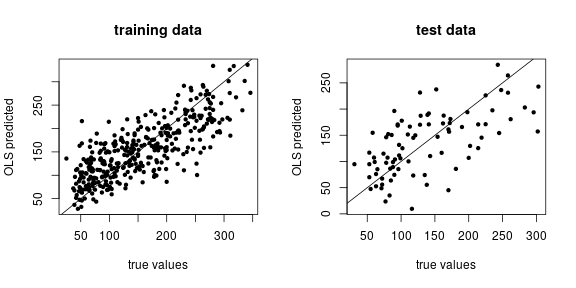

```r
plot(training_d$y, predict(ols), xlab="true values", ylab="OLS predicted", main="training data", pch=20)
abline(0,1)
plot(test_d$y, ols_pred, xlab="true values", ylab="OLS predicted", main="test data", pch=20)
abline(0,1)
```

## A sparsifying prior

We have a lot of predictors: 64 of them. A good guess is that only a few are really useful. So, we can put a *sparsifying* prior on the coefficients, i.e., $\beta$s in
$$\begin{aligned}
y = \beta_0 + \beta_1 x_1 + \cdots \beta_n x_n + \epsilon
\end{aligned}$$

# Crossvalidation exploration

## Who says we don’t do experiments?

1. Simulate data with `y ~ a + b x[1] + c x[2]`, and fit a linear model.
2. Measure in-sample and out-of-sample prediction error.
3. Add spurious variables, and report the above as a function of number of variables.
4. Simulate data with *many, weakly predictive* explanatory variables.
5. Compare different methods for fitting linear models.

## (in-class)

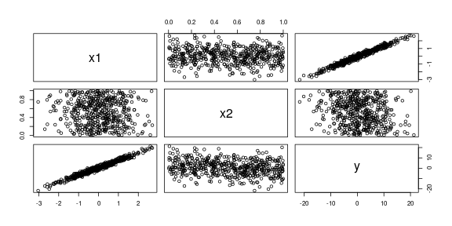

```r
set.seed(23)
N <- 500
df <- data.frame(x1 = rnorm(N),
                 x2 = runif(N))
params <- list(intercept = 2.0,
               x1 = 7.0,
               x2 = -3.0,
               sigma = 0.1 * 10)

pred_y <- params$intercept + params$x1 * df$x1 + params$x2 * df$x2
df$y <- rnorm(N, mean=pred_y, sd=params$sigma)

pairs(df)
```

```r
# write the crossvalidation error function

kfold <- function (K, df) {
    N <- nrow(df)
    Kfold <- sample(rep(1:K, N/K))

    do_xval <- function (k) {
        the_lm <- lm(y ~ ., data=df, subset=(Kfold != k))
        train_error <- sqrt(mean(resid(the_lm)^2))
        test_y <- df$y[Kfold == k]
        test_error <- sqrt(mean( (test_y - predict(the_lm, newdata=subset(df, Kfold==k)))^2 ))
        return(c('test'=test_error, 'train'=train_error))
    }

    results <- sapply(1:K, do_xval)
    return(results)
}
```

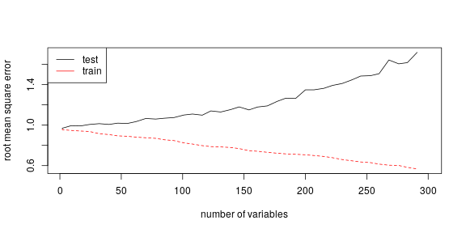

```r
K <- 10
max_M <- 300
do_m <- floor(seq(from=2, to=max_M-1, length.out=40))
all_results <- matrix(NA, nrow=length(do_m) + 1, ncol=2)
first_results <- rowMeans(kfold(K, df))
all_results[1,] <- first_results
colnames(all_results) <- names(first_results)

noise_df <- matrix(rnorm(N * (N-2)), nrow=N)
colnames(noise_df) <- paste0('z', 1:ncol(noise_df))
new_df <- cbind(df, noise_df)
for (j in seq_along(do_m)) {
    m <- do_m[j]
    all_results[j,] <- rowMeans(kfold(K, new_df[,1:(m+1)]))
}

matplot(c(2, do_m), all_results, type='l', xlab='number of variables', ylab='root mean square error')
legend("topleft", lty=1, col=1:2, legend=colnames(all_results))
```

# Generated quantities

## Another approach

For interpretation, we looked at parameter estimates, and relied on strong priors to deal with model nonidentifiability.

A possibly better alternative is to ask for the posterior distribution of the quantities we actually want to know (not the same as the parameters, in this case).

## Once more:

```r
go_model_code3 <- "
data {
    int nterms;
    int ntop; // number of 'top' categories
    int N[nterms];
    int U[nterms];
    int D[nterms];
    int top[nterms];
}
parameters {
    vector[nterms] alpha;
    vector[2] delta; // up, down regulation
    vector[ntop] beta1;
    vector[nterms] beta2;
    vector[nterms] gamma;
}
transformed parameters {
    vector[nterms] mean_n;
    vector[nterms] mean_u;
    vector[nterms] mean_d;
    mean_n = exp(alpha);
    mean_u = exp(alpha + delta[1] + beta1[top] + beta2);
    mean_d = exp(alpha + delta[2] + beta1[top] + beta2 + gamma);
}
model {
    N ~ poisson(mean_n);
    U ~ poisson(mean_u);
    D ~ poisson(mean_d);
    alpha ~ normal(0, 5); // flat-ish
    delta ~ normal(0, 5); // flat-ish
    beta1 ~ cauchy(0, 1.0);
    beta2 ~ cauchy(0, 1.0);
    gamma ~ cauchy(0, 1.0);
}
"
go_model3 <- stan_model(model_code=go_model_code3)
```

## Fit, again

```r
go_fit3 <- sampling(go_model3, chains = 4, iter = 4000,
                    data=list(nterms = nrow(goterms),
                              ntop = nlevels(goterms$top),
                              N = goterms$num_genes - goterms$upregulated - goterms$downregulated,
                              U = goterms$upregulated,
                              D = goterms$downregulated,
                              top = as.numeric(goterms$top)))
```

```
##                mean se_mean     sd     2.5%      25%      50%      75%      98% n_eff Rhat
## alpha[1]    7.7e+00 0.00018  0.021  7.7e+00  7.7e+00  7.7e+00     7.72  7.7e+00 13309    1
## alpha[2]    6.7e+00 0.00031  0.035  6.6e+00  6.7e+00  6.7e+00     6.73  6.8e+00 12903    1
## alpha[3]    3.4e+00 0.00164  0.180  3.0e+00  3.3e+00  3.4e+00     3.50  3.7e+00 12168    1
## alpha[4]    5.7e+00 0.00049  0.056  5.6e+00  5.7e+00  5.7e+00     5.76  5.8e+00 12993    1
## alpha[5]    7.3e+00 0.00023  0.026  7.2e+00  7.3e+00  7.3e+00     7.30  7.3e+00 12927    1
## alpha[6]    7.1e+00 0.00024  0.030  7.0e+00  7.0e+00  7.1e+00     7.08  7.1e+00 15034    1
## alpha[7]    6.0e+00 0.00041  0.049  5.9e+00  6.0e+00  6.0e+00     6.06  6.1e+00 14320    1
## alpha[8]    3.9e+00 0.00131  0.144  3.6e+00  3.8e+00  3.9e+00     3.96  4.1e+00 12104    1
## alpha[9]    4.8e+00 0.00078  0.094  4.6e+00  4.7e+00  4.8e+00     4.85  5.0e+00 14465    1
## alpha[10]   7.3e+00 0.00021  0.025  7.3e+00  7.3e+00  7.3e+00     7.37  7.4e+00 14685    1
## alpha[11]   4.5e+00 0.00089  0.105  4.3e+00  4.5e+00  4.5e+00     4.61  4.7e+00 13918    1
## delta[1]   -2.4e+00 0.01434  0.823 -3.9e+00 -2.9e+00 -2.4e+00    -1.88 -7.2e-01  3289    1
## delta[2]   -3.1e+00 0.01574  0.874 -4.8e+00 -3.7e+00 -3.2e+00    -2.57 -1.4e+00  3083    1
## beta1[1]   -2.7e-01 0.01324  0.868 -2.2e+00 -7.6e-01 -2.3e-01     0.26  1.4e+00  4298    1
## beta1[2]    6.3e-01 0.01444  0.863 -1.0e+00  7.3e-02  6.1e-01     1.15  2.3e+00  3573    1
## beta1[3]   -7.5e-01 0.01500  0.930 -2.8e+00 -1.3e+00 -6.6e-01    -0.13  8.9e-01  3847    1
## beta2[1]   -2.4e-01 0.01185  0.651 -1.7e+00 -6.1e-01 -1.9e-01     0.17  9.0e-01  3014    1
## beta2[2]   -3.4e-01 0.01218  0.656 -1.8e+00 -7.0e-01 -2.9e-01     0.08  8.1e-01  2905    1
## beta2[3]   -3.2e-01 0.01284  0.810 -2.2e+00 -7.5e-01 -2.4e-01     0.21  1.1e+00  3984    1
## beta2[4]    3.1e+00 0.01196  0.655  1.6e+00  2.7e+00  3.1e+00     3.49  4.2e+00  2999    1
## beta2[5]   -4.0e-02 0.00710  0.453 -9.3e-01 -3.3e-01 -4.6e-02     0.23  8.8e-01  4074    1
## beta2[6]    3.7e-01 0.00718  0.454 -5.2e-01  7.8e-02  3.6e-01     0.65  1.3e+00  4000    1
## beta2[7]    2.7e-02 0.00719  0.460 -8.7e-01 -2.7e-01  2.0e-02     0.31  9.8e-01  4091    1
## beta2[8]    5.4e-02 0.00729  0.510 -9.5e-01 -2.8e-01  4.4e-02     0.38  1.1e+00  4905    1
## beta2[9]   -6.0e-01 0.00975  0.761 -2.3e+00 -1.0e+00 -5.5e-01    -0.11  7.8e-01  6103    1
## beta2[10]   2.9e-01 0.00853  0.642 -9.6e-01 -1.1e-01  2.7e-01     0.67  1.6e+00  5670    1
## beta2[11]  -3.0e-01 0.00923  0.709 -1.8e+00 -7.1e-01 -2.7e-01     0.15  1.1e+00  5906    1
## gamma[1]    1.7e-01 0.00559  0.326 -4.6e-01 -4.4e-02  1.6e-01     0.38  8.2e-01  3394    1
## gamma[2]    2.1e-01 0.00594  0.366 -5.0e-01 -3.6e-02  2.1e-01     0.45  9.3e-01  3791    1
## gamma[3]   -3.4e+00 0.81222 13.167 -2.0e+01 -2.5e+00 -1.0e+00    -0.19  9.1e-01   263    1
## gamma[4]   -5.9e-01 0.00574  0.313 -1.2e+00 -8.0e-01 -5.9e-01    -0.39  2.5e-02  2986    1
## gamma[5]    3.3e-03 0.00589  0.315 -6.3e-01 -2.0e-01  5.5e-03     0.21  6.2e-01  2863    1
## gamma[6]   -6.6e-02 0.00562  0.315 -6.8e-01 -2.7e-01 -6.2e-02     0.14  5.6e-01  3142    1
## gamma[7]   -3.5e-01 0.00608  0.362 -1.1e+00 -5.8e-01 -3.4e-01    -0.11  3.7e-01  3544    1
## gamma[8]    8.2e-02 0.00617  0.523 -9.8e-01 -2.5e-01  8.3e-02     0.42  1.1e+00  7190    1
## gamma[9]    1.0e+00 0.00884  0.746 -3.0e-01  4.9e-01  9.7e-01     1.50  2.6e+00  7108    1
## gamma[10]   1.3e-01 0.00557  0.333 -5.3e-01 -8.5e-02  1.3e-01     0.35  7.9e-01  3564    1
## gamma[11]   8.1e-02 0.00767  0.737 -1.5e+00 -3.5e-01  9.6e-02     0.53  1.5e+00  9232    1
## mean_n[1]   2.2e+03 0.39863 46.158  2.1e+03  2.2e+03  2.2e+03  2243.36  2.3e+03 13408    1
```

[output cut: 18 more lines]

```
## mean_u[9]   3.3e+00 0.01622  1.638  8.6e-01  2.1e+00  3.0e+00     4.17  7.1e+00 10199    1
## mean_u[10]  9.1e+01 0.09924  9.352  7.3e+01  8.4e+01  9.1e+01    97.10  1.1e+02  8881    1
## mean_u[11]  3.4e+00 0.01521  1.596  1.1e+00  2.2e+00  3.1e+00     4.20  7.2e+00 11012    1
## mean_d[1]   7.0e+01 0.09005  8.221  5.5e+01  6.4e+01  6.9e+01    74.99  8.7e+01  8334    1
## mean_d[2]   2.5e+01 0.04858  4.856  1.6e+01  2.1e+01  2.4e+01    27.76  3.5e+01  9993    1
## mean_d[3]   4.2e-01 0.00674  0.513  1.2e-09  5.8e-02  2.5e-01     0.59  1.8e+00  5798    1
## mean_d[4]   1.2e+02 0.11886 11.129  1.0e+02  1.2e+02  1.2e+02   131.18  1.5e+02  8768    1
## mean_d[5]   1.2e+02 0.11893 10.633  9.7e+01  1.1e+02  1.2e+02   124.10  1.4e+02  7993    1
## mean_d[6]   1.3e+02 0.12655 11.451  1.1e+02  1.2e+02  1.3e+02   138.60  1.5e+02  8188    1
## mean_d[7]   2.6e+01 0.05149  4.985  1.7e+01  2.2e+01  2.5e+01    28.71  3.6e+01  9374    1
## mean_d[8]   4.9e+00 0.02044  2.046  1.8e+00  3.4e+00  4.6e+00     6.05  9.8e+00 10021    1
## mean_d[9]   4.3e+00 0.02097  1.991  1.4e+00  2.8e+00  4.0e+00     5.36  9.1e+00  9009    1
## mean_d[10]  5.0e+01 0.07244  6.974  3.7e+01  4.5e+01  5.0e+01    54.42  6.4e+01  9267    1
## mean_d[11]  1.9e+00 0.01164  1.178  3.6e-01  1.1e+00  1.7e+00     2.49  4.9e+00 10244    1
## lp__        5.8e+04 0.10390  4.800  5.8e+04  5.8e+04  5.8e+04 58072.58  5.8e+04  2134    1
```

## What do we want to know?

Let $\mu^N_i = \exp(\lambda^N_i)$ and $\mu^N = \sum_i \mu^N_i$.

Is term $i$ overrepresented among differentially regulated genes?
$$\begin{aligned}
\frac{ (\mu^U_i + \mu^D_i) / (\mu^U + \mu^D) }
{ \mu^N_i / \mu^N }
\end{aligned}$$

Is term $i$ more up- than down-regulated?
$$\begin{aligned}
\frac{ \mu^U_i / \mu^U }
{ \mu^D_i / \mu^D }
\end{aligned}$$

## Posterior distributions: GO term enrichments

```r
samps <- rstan::extract(go_fit3)
diff_enrichment <- ((samps$mean_d + samps$mean_u) / (rowSums(samps$mean_d) + rowSums(samps$mean_u))) / (samps$mean_n / rowSums(samps$mean_n))
up_enrichment <- (samps$mean_u / rowSums(samps$mean_u)) / (samps$mean_d / rowSums(samps$mean_d))
colnames(diff_enrichment) <- paste0("diff:", goterms$term)
colnames(up_enrichment) <- paste0("up:", goterms$term)

diff_top_enrichment <- (simplify2array(by(t(samps$mean_u + samps$mean_d), goterms$top, colSums))  / rowSums(samps$mean_u)) / (simplify2array(by(t(samps$mean_n), goterms$top, colSums))/ rowSums(samps$mean_n))
up_top_enrichment <- (simplify2array(by(t(samps$mean_u), goterms$top, colSums))  / rowSums(samps$mean_u)) / (simplify2array(by(t(samps$mean_d), goterms$top, colSums))/ rowSums(samps$mean_d))
colnames(diff_top_enrichment) <- paste0("diff:", levels(goterms$top))
colnames(up_top_enrichment) <- paste0("up:", levels(goterms$top))
```

## Posterior distributions: GO term enrichments

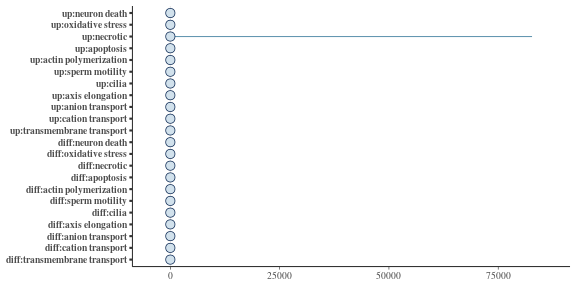

```r
bayesplot::mcmc_intervals(cbind(up_enrichment, diff_enrichment))
```

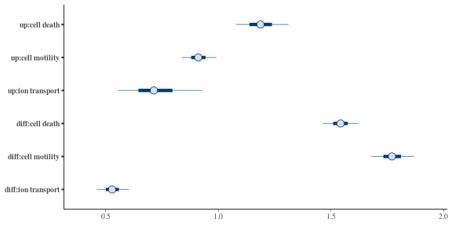

```r
bayesplot::mcmc_intervals(cbind(up_top_enrichment, diff_top_enrichment))
```

## log scale

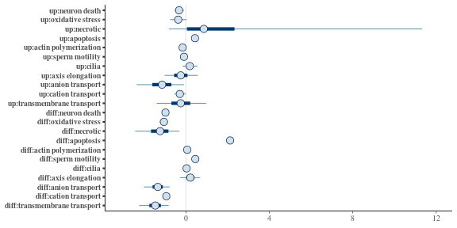

```r
bayesplot::mcmc_intervals(log(cbind(up_enrichment, diff_enrichment)))
```

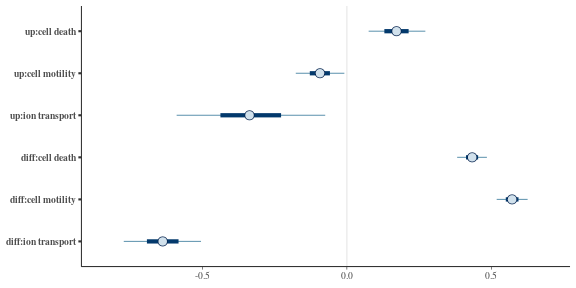

```r
bayesplot::mcmc_intervals(log(cbind(up_top_enrichment, diff_top_enrichment)))
```